# Report

Francesco Andreini

19 April 2018

## Loading and preprocessing the data

Show any code that is needed to:  
1. Load the data (i.e. read.csv());  
2. Process/transform the data (if necessary) into a format suitable for your analysis - we consider dates as factors.

```r
data<-read.csv("activity.csv",sep=",")
data$date<-as.factor(data$date)
```

See the head of the file to check its shape.

```r
head(data)
```

```
##   steps       date interval
## 1    NA 2012-10-01        0
## 2    NA 2012-10-01        5
## 3    NA 2012-10-01       10
## 4    NA 2012-10-01       15
## 5    NA 2012-10-01       20
## 6    NA 2012-10-01       25
```

## What is mean total number of steps taken per day?

For this part of the assignment, you can ignore the missing values in the dataset. Make a histogram of the total number of steps taken each day (not barplot!).

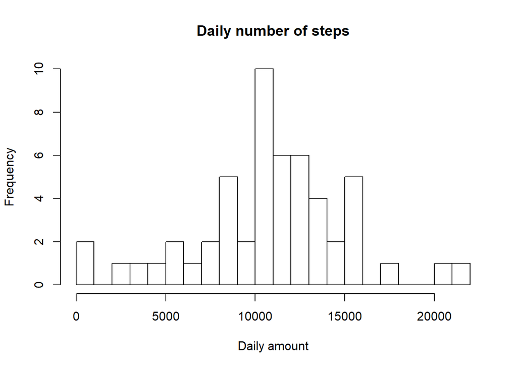

```r
data_agg<-aggregate(data$steps,by=list(data$date),FUN=sum)
hist(data_agg$x,xlab="Daily amount",main="Daily number of steps",breaks = 20)
```

Calculate and report the mean and median total number of steps taken per day.

```r
mean(data_agg$x,na.rm=T)
```

```
## [1] 10766.19
```

```r
median(data_agg$x,na.rm=T)
```

```
## [1] 10765
```

## What is the average daily activity pattern?

Make a time series plot (i.e. type = “l”) of the 5-minute interval (x-axis) and the average number of steps taken, averaged across all days (y-axis).

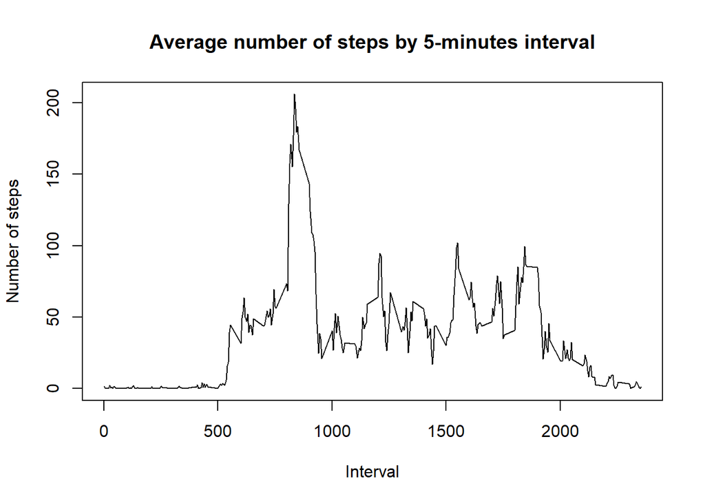

```r
data_interval_mean<-aggregate(steps~interval,data=data,FUN=mean)
plot(data_interval_mean,type="l",xlab="Interval",ylab="Number of steps",main="Average number of steps by 5-minutes interval")
```

```r
data_interval_mean[data_interval_mean$steps==max(data_interval_mean$steps),]
```

```
##     interval    steps
## 104      835 206.1698
```

## Imputing missing values

Calculate and report the total number of missing values in the dataset (i.e. the total number of rows with NAs).

```r
sum(!complete.cases(data))
```

```
## [1] 2304
```

Fill in all of the missing values in the dataset by using the mean for that 5-minute interval. Create a new dataset that is equal to the original dataset but with the missing data filled in.

```r
data2<-read.csv("activity.csv",sep=",")
data2$date<-as.factor(data2$date)
for (x in 1:nrow(data2)){
  if (is.na(data2[x,1])){
    row<-data_interval_mean[data_interval_mean$interval==data2[x,3],]
    data2[x,1]<-row[1,2]
  }
}
```

Make a histogram of the total number of steps taken each day.

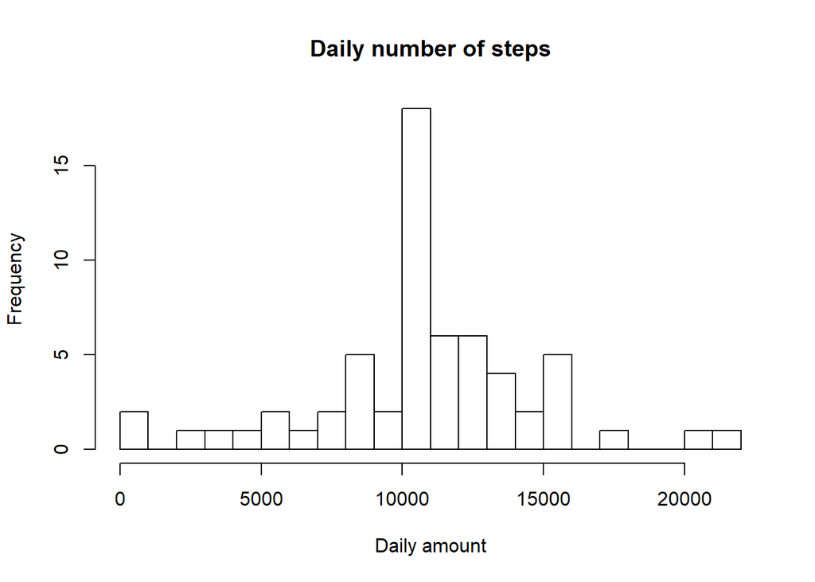

```r
data_agg2<-aggregate(data2$steps,by=list(data2$date),FUN=sum)
hist(data_agg2$x,xlab="Daily amount",main="Daily number of steps",breaks=20)
```

```r
mean(data_agg2$x)
```

```
## [1] 10766.19
```

```r
median(data_agg2$x)
```

```
## [1] 10766.19
```

Comparing these two values with previous data, means are identical while medians are different.

# Are there differences in activity patterns between weekdays and weekends?

Create a new factor variable in the dataset with two levels - “weekday” and “weekend” indicating whether a given date is a weekday or weekend day. For this part the weekdays() function may be of some help here. Use the dataset with the filled-in missing values for this part.

```r
data3<-data2
days<-c()
for (x in 1:nrow(data3)){
  days<-c(days,weekdays(as.Date(data3[x,2])))
}
data3<-cbind(data3,days)
weekend<-c()
for (x in 1:nrow(data3)){
  if (data3[x,4]=="Saturday"|data3[x,4]=="Sunday"){
    weekend<-c(weekend,"Weekend")
  } else {weekend<-c(weekend,"Weekday")}
}
data3<-cbind(data3,weekend)
data3$weekend=as.factor(data3$weekend)
data_interval_mean3<-aggregate(steps ~ interval + weekend,data=data,FUN=mean)
```

Make a panel plot containing a time series plot (i.e. type = “l”) of the 5-minute interval (x-axis) and the average number of steps taken, averaged across all weekday days or weekend days (y-axis).

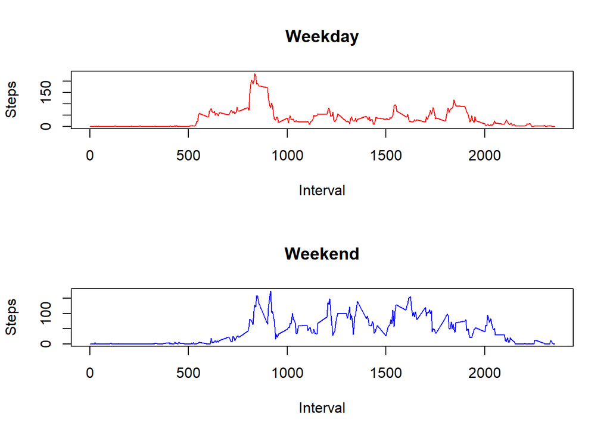

```r
par(mfrow=c(2,1),pty="m")
plot(data_interval_mean3[data_interval_mean3$weekend=="Weekday",c(1,3)],type="l",col="red",main="Weekday",xlab="Interval",ylab="Steps")
plot(data_interval_mean3[data_interval_mean3$weekend=="Weekend",c(1,3)],type="l",col="blue",main="Weekend",xlab="Interval",ylab="Steps")
```

The patterns show that people usually reach their peak of activity during weekdays, while they go to sleep later in the weekend.